# Quarto 導入手順 (Windows)

R GUI + テキストエディタ + ターミナル。RStudio は使いません

作者

アジア経済研究所 伊藤成朗の指示のもと claude opus 5 が作成

公開

2026年9月27日

上から順に実施してください。使う道具は4つで、互いに独立しています。

| 道具 | 役割 |
| --- | --- |
| R | 計算と作図 |
| テキストエディタ | `.qmd` ファイルを書く |
| ターミナル | コマンドを打つ |
| Quarto | `.qmd` を html / pdf / docx に変換する |

# 1 ターミナルとは

- 画面にコマンドを1行打ち込み、Enter で実行するための窓
- マウスで押すボタンの代わりに、名前を打って命令する
- Windows には2種類ある — **PowerShell**（新しい）と **コマンドプロンプト `cmd`**（古い）

開き方: Windows キーを押し、`powershell` または `cmd` と打って Enter。

よく使う4つだけ覚えれば足ります。

| 打つもの | すること |
| --- | --- |
| `cd フォルダ名` | そのフォルダへ移動する |
| `cd ..` | 1つ上のフォルダへ戻る |
| `dir` | いまのフォルダの中身を並べる |
| `exit` | ターミナルを閉じる |

貼り付けは右クリックです。

# 2 インストレーション

## 2.1 ターミナル

一度打ったコマンドを一覧から選べます。PowerShell と コマンドプロンプトで やり方が違うので、使う方だけ読んでください。

|  | PowerShell | コマンドプロンプト |
| --- | --- | --- |
| 必要なもの | PowerShell 7 (PSReadLine 同梱) | clink |
| 履歴を一覧から選ぶ | ↑↓ で選べる一覧。既定は切、下の1行で入 | `F7` または `Ctrl+Alt+↑` |
| 履歴を検索 | `Ctrl+R` | `Ctrl+R` |

### 2.1.1 PowerShell 7

[入手先](https://learn.microsoft.com/ja-jp/powershell/scripting/install/installing-powershell-on-windows)。 ターミナルに貼り付けても入ります。

```powershell
winget install --id Microsoft.PowerShell -e
```

[figure not shown]

PowerShell 7 のインストール手順ページ。MSI パッケージのリンクから入れます

### 2.1.2 コマンドプロンプト

履歴の一覧が出ます。

## 2.2 R

### 2.2.1 バイナリ(実行ファイル)

https://cran.r-project.org/bin/windows/base/ を開き、いちばん上の **Download R-x.x.x for Windows** を押します。落ちてきた `.exe` を実行し、 すべて既定のまま進みます。

- multiple window (single windowではない)を選ぶことをお薦めします

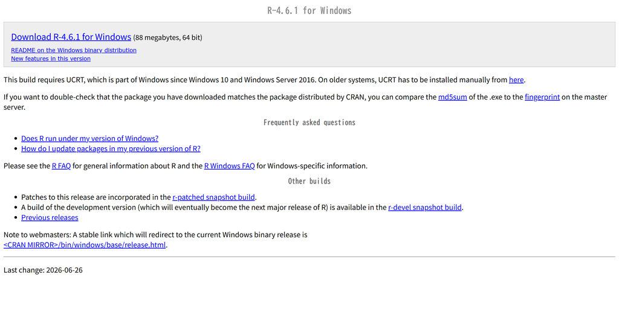

CRAN の Windows 版ページ。上端のリンク1つだけ押します

起動は、スタートメニューの「**R x64 4.x.x**」です。黒い窓ではなく、 `R Console` という白い窓が出ます。これが R GUI です。

### 2.2.2 ライブラリ

R GUI の `R Console` 窓に、次の1行を貼って Enter。数分かかります。

```r
install.packages(c("quarto", "rmarkdown", "knitr", "ggplot2"))
```

途中でミラーサイトを聞かれたら `Japan` のどれかを選びます。

### 2.2.3 Pandoc

rmarkdown は変換に Pandoc を使います。 入っているか確かめます。

```r
rmarkdown::pandoc_available()
```

`FALSE` なら https://pandoc.org/installing.html から Windows 用の `.msi` を入れ、R を開き直します。`TRUE` なら次へ。

## 2.3 Quarto

### 2.3.1 実行ファイル

https://quarto.org/docs/download/ を開き、**Download Quarto CLI** を押します。 落ちてきた `.msi` を実行し、すべて既定のまま進みます。

[figure not shown]

Quarto のダウンロードページ。青いボタン、または表の Windows 行の .msi

入ったか確かめます。ターミナルに貼って Enter。

```
quarto check
```

### 2.3.2 Pandoc

Quarto には Pandoc が同梱されています。Quarto のために別途入れる必要はありません。

## 2.4 テキスト・エディタ

どちらか1つで足ります。両方入れる必要はありません。

表 1: サクラエディタと Notepad++ の比較

| くらべる点 | サクラエディタ | Notepad++ |
| --- | --- | --- |
| ライセンス | zlib | GPLv3 以降 |
| 最新版 (2026年9月時点) | 2.4.3 (2026年8月) | 8.9.8 |
| 対応 Windows | 32bit 版のみ配布 | 64bit / 32bit / ARM64 |
| 画面の言語 | 日本語のみ | 90 言語。既定は英語、設定で日本語に |
| 入れ方 | インストーラ zip / 実行ファイル zip | インストーラ / portable zip (展開するだけ) |
| 最初から色が付く言語 | R と Markdown は自分で追加する | 78 言語。ただし R は入っていない |
| R の色分け | R3.kwd を強調キーワードに取り込む | R_by-halpo.xml をユーザー定義言語に取り込む |
| Markdown の色分け | .rkw と .col の 2 ファイル | UDL の xml 1 ファイル |
| 文字コード | Shift_JIS, ISO-2022-JP, EUC-JP, UTF-16, UTF-8, UTF-7 | UTF-8 ほか。「エンコード」メニューから選ぶ |
| 拡張のしかた | マクロ (VBScript / JScript) | プラグイン 140 以上 (10 個は最初から) |
| 複数ファイル検索 (Grep) | あり | あり |
| 向いている人 | 英語の画面を避けたい人 | 設定ファイルを少なくしたい人、USB メモリで持ち歩きたい人 |

出典: [Notepad++ (Wikipedia)](https://en.wikipedia.org/wiki/Notepad%2B%2B)、 Sakura (Wikipedia)、 両者の配布ページ。

### 2.4.1 サクラエディタ

https://sakura-editor.github.io/ の「インストーラ、パッケージダウンロード」から 落として実行します。画面は日本語です。

[figure not shown]

サクラエディタ公式サイト。最新版ダウンロードから入ります

### 2.4.2 Notepad++ ポータブル版

https://notepad-plus-plus.org/downloads/ の最新版を開き、 **portable x64 (zip)** を落とします。zip を好きなフォルダに展開するだけで、 インストールは不要です。

[figure not shown]

Notepad++ のダウンロードページ。最新版を選び、portable zip を落とします

日本語表示は `Settings` → `Preferences` → `General` → `Localization` → `日本語`。

# 3 設定

このセクションは便利機能なので省略可能です。

## 3.1 色分け(強調)表示

`.qmd` の中の R コードと markdown に色が付きます。使うエディタの欄だけ読んでください。

### 3.1.1 サクラエディタ

**R**

1. https://github.com/kazwd2008/Sakura を開く
2. `R3.kwd` を押し、`Download raw file` で保存する
3. サクラエディタ → 設定 → 共通設定 → 強調キーワード
4. 「セット追加」を押し、セット名に `R` と入れる
5. 「インポート」を押し、保存した `R3.kwd` を選ぶ

[figure not shown]

R3.kwd の配布ページ

**Markdown**

[解説記事](https://keitetsu.blogspot.com/2021/03/markdown.html)の手順です。

1. https://github.com/KeitetsuWorks/Sakura_Monokai を開き、`Code` → `Download ZIP` で保存して展開する
2. サクラエディタ → 設定 → タイプ別設定一覧 → 「インポート」
3. 展開したフォルダの `markdown_monokai/markdown_monokai.ini` を選ぶ (バージョンの確認が出たら「OK」)
4. 「インポート確認」で「読込先:」を「新規追加」にして「OK」
5. 「ファイルをインポートしました。」と出れば完了。一覧に Markdown (md) が加わります

[figure not shown]

Markdown 設定の配布ページ。`Code` → `Download ZIP`

**`.qmd` を markdown 扱いにする**

設定 → タイプ別設定一覧 → Markdown のタイプを選ぶ → 「設定」→ 「ファイル拡張子」に `qmd` を足す。

### 3.1.2 Notepad++

**R**

1. https://github.com/notepad-plus-plus/userDefinedLanguages/blob/master/udl-list.md を開き、`R language` 行の `R_by-halpo.xml` を保存する
2. Notepad++ → 言語 → ユーザー定義言語 → 定義をインポート
3. 保存した xml を選び、Notepad++ を再起動する

[figure not shown]

Notepad++ の定義ファイル一覧。R language の行

**Markdown**

同じ手順で [`markdown.default.udl.xml`](https://raw.githubusercontent.com/Edditoria/markdown-plus-plus/master/udl/markdown.default.udl.xml) を入れます。

**`.qmd` を markdown 扱いにする**

設定 → スタイル設定 → 左下の「ユーザー定義拡張子」に `qmd` を足す。

### 3.1.3 設定が効いたかの確認

設定後のエディタで `.qmd` と R ファイルを開くと、次のように色が付きます。

[figure not shown]

Notepad++: `.qmd`

[figure not shown]

Notepad++: R ファイル

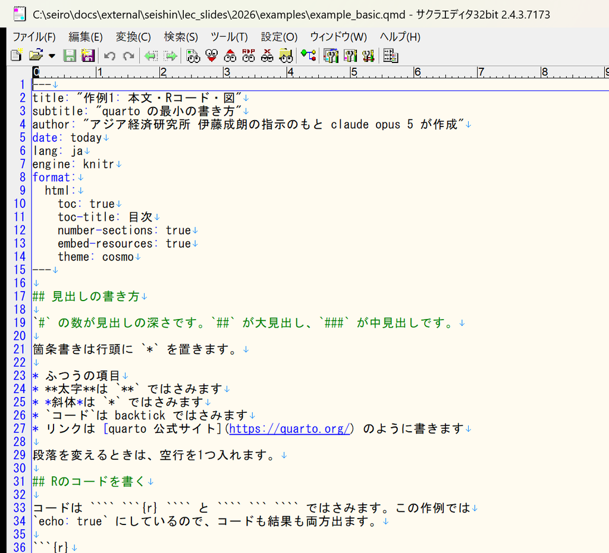

サクラエディタ: `.qmd`(R のキーワードに色)

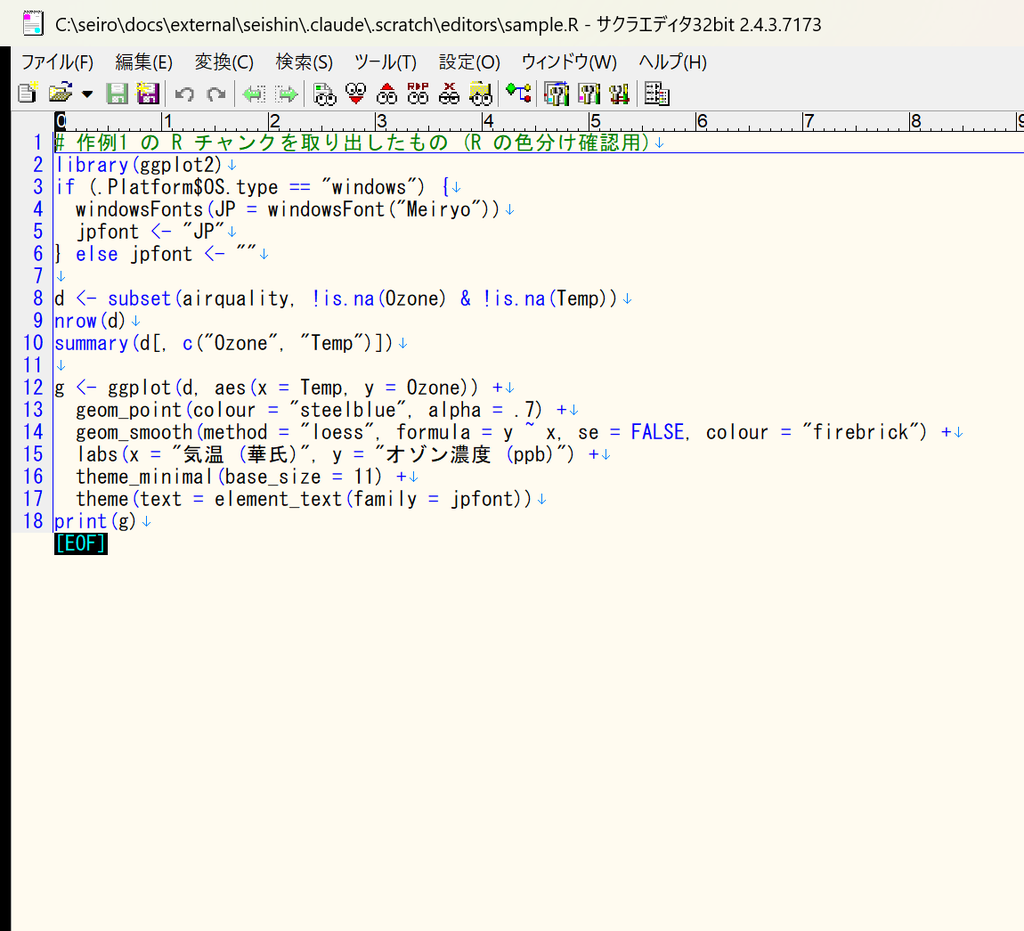

サクラエディタ: R ファイル

### 3.1.4 reveal.js について

reveal.js 専用の色分けファイルはありません。スライドの記法 (`----`、`::: {.fragment}`) は markdown の色分けでそのまま色が付きます。

## 3.2 文字コード

日本語が化けないように、保存形式をUTF-8に固定します。

- サクラエディタ: 設定 → タイプ別設定 → 「ウィンドウ」タブ → 文字コードセット → `UTF-8`
- Notepad++: エンコード → `UTF-8` (BOM なし)

## 3.3 ターミナル用履歴表示

### 3.3.1 PowerShell

一覧表示設定(今セッションのみ)

```powershell
Set-PSReadLineOption -PredictionSource History -PredictionViewStyle ListView
```

一覧表示設定(今セッション+以降)

```powershell
if (!(Test-Path $PROFILE)) { New-Item -ItemType File -Path $PROFILE -Force }
Add-Content $PROFILE 'Set-PSReadLineOption -PredictionSource History -PredictionViewStyle ListView'
```

### 3.3.2 コマンド・プロンプト用clink

[入手先](https://github.com/chrisant996/clink/releases)。`clink.<版>.setup.exe` を 落として実行します。

```powershell
winget install --id chrisant996.Clink -e
```

[figure not shown]

clink の Releases ページ。Assets の中の setup.exe を落とします

入れたあとは `F7` で一覧表示設定(1セッション限り)

# 4 実行方法

## 4.1 quarto

`bunsho.qmd` を作業フォルダに置いた状態で、どちらかを実行します。

### 4.1.1 R GUI から

`R Console` 窓に貼ります。

```r
setwd("C:/Users/自分の名前/Documents/quarto")
quarto::quarto_render("bunsho.qmd")
```

### 4.1.2 ターミナルから

```
cd C:\Users\自分の名前\Documents\quarto
quarto render bunsho.qmd
```

同じフォルダに `bunsho.html` ができます。ダブルクリックで開きます。

## 4.2 RMarkdown (.Rmd) と litedown (.md)

Quarto を使わず、R だけで `.Rmd` や `.md` を html にする方法です。 どちらも `R Console` 窓に貼って実行します。

| ファイル | パッケージ | 関数 | Pandoc |
| --- | --- | --- | --- |
| `.Rmd` | rmarkdown | `rmarkdown::render()` | 必要 |
| `.Rmd` | litedown | `litedown::fuse()` | 不要 |
| `.md` | litedown | `litedown::mark()` | 不要 |

### 4.2.1 RMarkdown (.Rmd)

Quarto を入れていれば、Pandoc も一緒に入っています。ただし rmarkdown は それを自動では見つけません。`rmarkdown::pandoc_available()` が `FALSE` のときは、 Pandoc を別に入れる代わりに、次の1行で Quarto の Pandoc を使わせることができます (R を開くたびに1回)。

```r
Sys.setenv(RSTUDIO_PANDOC = dirname(list.files(file.path(dirname(quarto::quarto_path()), "tools"), pattern = "^pandoc(\\.exe)?$", recursive = TRUE, full.names = TRUE)[1]))
rmarkdown::pandoc_available()
```

`TRUE` と出れば準備完了です。

```r
setwd("C:/Users/自分の名前/Documents/quarto")
rmarkdown::render("bunsho.Rmd")
```

### 4.2.2 litedown (.Rmd / .md)

litedown は Pandoc なしで動きます。最初に1回だけ入れます。

```r
install.packages("litedown")
```

R コードを含む `.Rmd` は `fuse()`、R コードのない `.md` は `mark()` です。

```r
setwd("C:/Users/自分の名前/Documents/quarto")
litedown::fuse("bunsho.Rmd")
litedown::mark("memo.md")
```

どの方法でも、同じフォルダに同じ名前の `.html` (`bunsho.html`、`memo.html`) ができます。

# 5 例

## 5.1 作例1: 本文・Rコード・図

作例1を開く ・ qmd を見る

`````markdown
---
title: "作例1: 本文・Rコード・図"
subtitle: "quarto の最小の書き方"
author: "アジア経済研究所 伊藤成朗の指示のもと claude opus 5 が作成"
date: today
lang: ja
engine: knitr
format:
  html:
    toc: true
    toc-title: 目次
    number-sections: true
    embed-resources: true
    theme: cosmo
---

## 見出しの書き方

`#` の数が見出しの深さです。`##` が大見出し、`###` が中見出しです。

箇条書きは行頭に `*` を置きます。

* ふつうの項目
* **太字**は `**` ではさみます
* *斜体*は `*` ではさみます
* `コード`は backtick ではさみます
* リンクは [quarto 公式サイト](https://quarto.org/) のように書きます

段落を変えるときは、空行を1つ入れます。

## Rのコードを書く

コードは ```` ```{r} ```` と ```` ``` ```` ではさみます。この作例では
`echo: true` にしているので、コードも結果も両方出ます。

```{r}
#| label: setup
#| warning: false
#| message: false
library(ggplot2)
#### 図の中で日本語を使う準備(Windowsのみ)。これをしないと文字が四角になります
if (.Platform$OS.type == "windows") {
  windowsFonts(JP = windowsFont("Meiryo"))
  jpfont <- "JP"
} else jpfont <- ""
d <- subset(airquality, !is.na(Ozone) & !is.na(Temp))
nrow(d)
```

`airquality` は R に最初から入っているデータです。ダウンロードは要りません。

```{r}
summary(d[, c("Ozone", "Temp")])
```

## 図を作る

チャンクに `#| label: fig-` で始まる名前と `#| fig-cap:` を付けると、図に番号が
付き、本文から参照できます。

```{r}
#| label: fig-ozone
#| fig-cap: "気温とオゾン濃度(ニューヨーク市, 1973年5〜9月)"
#| fig-width: 6
#| fig-height: 4
g <- ggplot(d, aes(x = Temp, y = Ozone)) +
  geom_point(colour = "steelblue", alpha = .7) +
  geom_smooth(method = "loess", formula = y ~ x, se = FALSE, colour = "firebrick") +
  labs(x = "気温 (華氏)", y = "オゾン濃度 (ppb)") +
  theme_minimal(base_size = 11) +
  theme(text = element_text(family = jpfont))
print(g)
```

@fig-ozone のように書くと「図 1」という番号が自動で入ります。番号を自分で
数える必要はありません。

## 出力形式を変える

冒頭のヘッダ(YAML header)の `format:` を書き換えるだけです。

| 書き方 | 出力 |
|---|---|
| `format: html` | ウェブページ |
| `format: docx` | Word |
| `format: pdf` | PDF (別途 LaTeX が要ります) |
| `format: revealjs` | スライド |
`````

## 5.2 作例2: Tufte 風(傍注レイアウト)

作例2を開く ・ qmd を見る

````markdown
---
title: "作例2: Tufte 風(傍注レイアウト)"
subtitle: "作例1と中身は同じ。ヘッダだけが違う"
author: "アジア経済研究所 伊藤成朗の指示のもと claude opus 5 が作成"
date: today
lang: ja
engine: knitr
format:
  html:
    grid:
      margin-width: 350px
    toc: false
    embed-resources: true
    theme: cosmo
reference-location: margin
citation-location: margin
cap-location: margin
---

## 何が違うか

右に広い余白があります。脚注・図・注記がその余白に出ます。[^1]

[^1]: これが傍注です。`[^1]` と書くだけで、ページ下ではなく右余白に出ます。

ヘッダに足したのは次の4行だけです。

```yaml
format:
  html:
    grid:
      margin-width: 350px
reference-location: margin
citation-location: margin
cap-location: margin
```

## 余白に文章を置く

`::: {.column-margin}` ではさんだものは余白に出ます。

::: {.column-margin}
余白の注記です。本文の流れを止めずに、補足や出典を置けます。
:::

本文はふつうに続きます。箇条書きも**太字**も作例1と同じです。

* `margin-width` を大きくすると余白が広がります
* `reference-location: margin` が脚注を余白に送ります
* `cap-location: margin` が図の説明文を余白に送ります

## 余白に図を置く

チャンクに `#| column: margin` を足すと、図が余白に入ります。

```{r}
#| label: fig-ozone-margin
#| fig-cap: "気温とオゾン濃度(ニューヨーク市, 1973年5〜9月)"
#| column: margin
#| fig-width: 4
#| fig-height: 3
#| warning: false
#| message: false
library(ggplot2)
#### 図の中で日本語を使う準備(Windowsのみ)
if (.Platform$OS.type == "windows") {
  windowsFonts(JP = windowsFont("Meiryo"))
  jpfont <- "JP"
} else jpfont <- ""
d <- subset(airquality, !is.na(Ozone) & !is.na(Temp))
ggplot(d, aes(x = Temp, y = Ozone)) +
  geom_point(colour = "steelblue", alpha = .7) +
  geom_smooth(method = "loess", formula = y ~ x, se = FALSE, colour = "firebrick") +
  labs(x = "気温 (華氏)", y = "オゾン濃度 (ppb)") +
  theme_minimal(base_size = 9) +
  theme(text = element_text(family = jpfont))
```

@fig-ozone-margin は余白に置いた図です。本文の幅を狭めずに図を見せられます。

## 本文いっぱいに広げる

逆に `#| column: page` を足すと、余白まで使って横に広がります。

```{r}
#| label: fig-ozone-wide
#| fig-cap: "同じデータを月ごとに分けたもの"
#| column: page
#| fig-width: 10
#| fig-height: 3
d$月 <- factor(d$Month, levels = 5:9, labels = paste0(5:9, "月"))
ggplot(d, aes(x = Temp, y = Ozone)) +
  geom_point(colour = "steelblue", alpha = .7) +
  facet_wrap(~ 月, nrow = 1) +
  labs(x = "気温 (華氏)", y = "オゾン濃度 (ppb)") +
  theme_minimal(base_size = 10) +
  theme(text = element_text(family = jpfont))
```
````